# Practical_6

Hasbini Laura

17 octobre 2022

# Classification evaluation

## Introduction

```r
library(MASS)
library(ISLR)
library(tidyverse)
library(pROC)
library(rpart)
```

```r
library(rpart.plot)
library(randomForest)
set.seed(45)
```

## Confusion matrix, continued

#### Question 1

“Create a logistic regression model lr_mod for this data using the formula response ~ . and create a confusion matrix based on a .5 cutoff probability.”

```r
treat <- read_csv("data/cardiovascular_treatment.csv")
treat %>% mutate(severity <- as.factor(severity),
                          gender <- as.factor(gender),
                          dose <- as.factor(dose),
                          response <- as.factor(response))
```

```
## # A tibble: 253 x 11
##    severity   age gender bb_score prior_cvd  dose response `severity <- as~
##    <chr>    <dbl> <chr>     <dbl>     <dbl> <dbl>    <dbl> <fct>
##  1 high      54.8 m         350.          0     2        1 high
##  2 low       59.5 f          99.7         0     2        0 low
##  3 low       55.4 f         445.          0     2        0 low
##  4 low       48.2 f         153.          0     2        1 low
##  5 low       54.5 f         251.          1     2        0 low
##  6 low       40.7 m         349.          0     2        1 low
##  7 low       61.2 f         148.          0     2        0 low
##  8 high      57.4 f         198.          1     3        1 high
##  9 low       42.0 f         308.          0     1        1 low
## 10 low       65.5 m         155.          0     2        0 low
## # ... with 243 more rows, and 3 more variables: `gender <-
## #   as.factor(gender)` <fct>, `dose <- as.factor(dose)` <fct>, `response
## #   <- as.factor(response)` <fct>
```

```r
lr_mod <- glm(response ~ ., "binomial", treat)

prob_lr <- predict(lr_mod, type="response")
pred_lr <- ifelse(prob_lr > .5, 1, 0)

matrix_lr <- table(true = treat$response, pred = pred_lr)
matrix_lr
```

```
##     pred
## true  0  1
##    0 78 49
##    1 35 91
```

#### Question 2

“Calculate the accuracy, true positive rate (sensitivity), the true negative rate (specificity), the false positive rate, the positive predictive value, and the negative predictive value. You can use the confusion matrix table on wikipedia. What can you say about the model performance? Which metrics are most relevant if this model were to be used in the real world?”

```r
TN <- matrix_lr[1,1]
FN <- matrix_lr[2,1]
FP <- matrix_lr[1,2]
TP <- matrix_lr[2,2]

Acc = (TP+TN)/(TP+FP+TN+FN)
TPR = TP/(TP+FN)
TNR = TN/(TN+FP)
FPR = FP /(TN+FP)
PPV = TP/(TP+FP)
NPV = TN/(TN+FN)

tibble(Acc = Acc,
       TPR = TPR,
       TNR = TNR,
       FPR = FPR,
       PPV = PPV,
       NPV = NPV)
```

```
## # A tibble: 1 x 6
##     Acc   TPR   TNR   FPR   PPV   NPV
##   <dbl> <dbl> <dbl> <dbl> <dbl> <dbl>
## 1 0.668 0.722 0.614 0.386  0.65 0.690
```

We are here looking at the quality of a model predicting disease. As a disease may have bad consequenses, we are mostly interested in finding all the people infected. In other words, we want to have a high specificity (TNR). This would mean that a patient predicted negative by the model, is in fact negative to the disease. Here this rate is worth 0.614 which is quite low for a disease prediction.

#### Question 3

“Create an LDA model lda_mod for the same prediction problem. Compare its performance to the LR model.”

```r
lda_mod <- lda(response ~ ., treat)

pred_lda <- predict(lda_mod)$class
matrix_lda <- table(true=treat$response, pred = pred_lda)

TN <- matrix_lda[1,1]
FN <- matrix_lda[2,1]
FP <- matrix_lda[1,2]
TP <- matrix_lda[2,2]

Acc = (TP+TN)/(TP+FP+TN+FN)
TPR = TP/(TP+FN)
TNR = TN/(TN+FP)
FPR = FP /(TN+FP)
PPV = TP/(TP+FP)
NPV = TN/(TN+FN)

tibble(Acc = Acc,
       TPR = TPR,
       TNR = TNR,
       FPR = FPR,
       PPV = PPV,
       NPV = NPV)
```

```
## # A tibble: 1 x 6
##     Acc   TPR   TNR   FPR   PPV   NPV
##   <dbl> <dbl> <dbl> <dbl> <dbl> <dbl>
## 1 0.668 0.722 0.614 0.386  0.65 0.690
```

We can see that the performances we are interested in are the same with this new method.

#### Question 4

“Compare the classification performance of lr_mod and lda_mod for the new patients in the data/new_patients.csv.”

```r
new_patients <- read_csv("data/new_patients.csv")
new_patients %>% mutate(severity <- as.factor(severity),
                        gender <- as.factor(gender),
                        dose <- as.factor(dose),
                        response <- as.factor(response))
```

```
## # A tibble: 50 x 11
##    severity   age gender bb_score prior_cvd  dose response `severity <- as~
##    <chr>    <dbl> <chr>     <dbl>     <dbl> <dbl>    <dbl> <fct>
##  1 high      71.6 m          298.         1     3        1 high
##  2 low       35.7 m          248.         0     2        1 low
##  3 low       53.3 m          199.         0     2        1 low
##  4 low       63.5 m          155.         0     2        0 low
##  5 low       51.0 m          204.         0     2        1 low
##  6 low       61.1 f          153.         1     2        1 low
##  7 low       57.1 m          199.         0     2        0 low
##  8 high      51.1 m          305.         1     3        1 high
##  9 high      45.7 m          150.         0     3        1 high
## 10 high      50.2 f          452.         1     3        1 high
## # ... with 40 more rows, and 3 more variables: `gender <-
## #   as.factor(gender)` <fct>, `dose <- as.factor(dose)` <fct>, `response
## #   <- as.factor(response)` <fct>
```

```r
pred_lda_new <- predict(lda_mod, newdata = new_patients)$class
prob_lr_new <- predict(lr_mod, newdata = new_patients)
pred_lr_new <- ifelse(prob_lr_new > .5, 1, 0)

matrix_lr_new <- table(true=new_patients$response, pred= pred_lr_new)
matrix_lr_new
```

```
##     pred
## true  0  1
##    0 23  4
##    1 15  8
```

```r
matrix_lda_new <- table(true = new_patients$response, pred=pred_lda_new)
matrix_lda_new
```

```
##     pred
## true  0  1
##    0 17 10
##    1  8 15
```

```r
TNR_lda_new = matrix_lda_new[1, 1] / (matrix_lda_new[1, 1] + matrix_lda_new[1, 2])
TNR_lr_new = matrix_lr_new[1, 1] / (matrix_lr_new[1, 1] + matrix_lr_new[1, 2])

TNR_lda_new
```

```
## [1] 0.6296296
```

```r
TNR_lr_new
```

```
## [1] 0.8518519
```

We can see that the TNR (specificity) rate is different between the two dataset. I seems that performances of the lr methods are better if our goal is not to miss anyone positive to the disease.

“Calculate the out-of-sample brier score for the lr_mod and give an interpretation of this number.”

```r
mean((prob_lr_new - (as.numeric(new_patients$response)-1))^2)
```

```
## [1] 1.13789
```

This score represents the mean squared difference between the probability estimated on the test set and the true class.

## ROC curve

#### Question 5

“Create two LR models: lr1_mod with severity, age, and bb_score as predictors, and lr2_mod with the formula response ~ age + I(age^2) + gender + bb_score * prior_cvd * dose. Save the predicted probabilities on the training data.”

```r
lr1_mod <- glm(response ~ severity + age + bb_score, family = "binomial", data = treat)
prob_lr1 <- predict(lr1_mod, type="response")

lr2_mod <- glm(response ~ age + I(age^2) + gender + bb_score*prior_cvd*dose, family = "binomial", data = treat)
prob_lr2 <- predict(lr2_mod, type="response")
```

#### Question 6

“Use the function roc() from the pROC package to create two ROC objects with the predicted probabilities: roc_lr1 and roc_lr2. Use the ggroc() method on these objects to create an ROC curve plot for each. Which model performs better? Why?”

```r
roc_lr1 <- roc(treat$response, prob_lr1)
roc_lr2 <- roc(treat$response, prob_lr2)
```

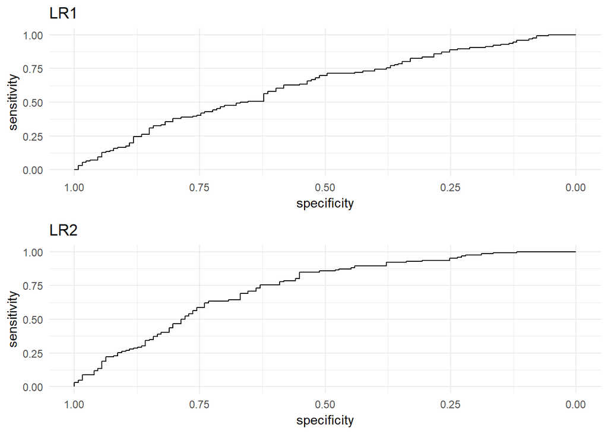

```r
roc_plot_lr1 <- ggroc(roc_lr1) + theme_minimal() + labs(title = 'LR1')
roc_plot_lr2 <- ggroc(roc_lr2) + theme_minimal() + labs(title = 'LR2')

cowplot::plot_grid(roc_plot_lr1, roc_plot_lr2, nrow = 2, align='v')
```

We can see that the LR2 curve is getting gloser to the upper left corner, which means this prediction model performs better.

#### Question 7

“Print the roc_lr1 and roc_lr2 objects. Which AUC value is higher? How does this relate to the plots you made before? What is the minimum AUC value and what would a “perfect” AUC value be and how would it look in a plot?"

```r
roc_lr1
```

```
##
## Call:
## roc.default(response = treat$response, predictor = prob_lr1)
##
## Data: prob_lr1 in 127 controls (treat$response 0) < 126 cases (treat$response 1).
## Area under the curve: 0.6253
```

```r
roc_lr2
```

```
##
## Call:
## roc.default(response = treat$response, predictor = prob_lr2)
##
## Data: prob_lr2 in 127 controls (treat$response 0) < 126 cases (treat$response 1).
## Area under the curve: 0.7325
```

Again, we can see that the area under the curve is bigger with lr_2. This suggest that lr_2 performs better.

A pefect AUC would be worth 1. With this feature, the curve will go in the upper left corner and be connect to (0,0) and (1,1) with straigt lines.

## Iris dataset

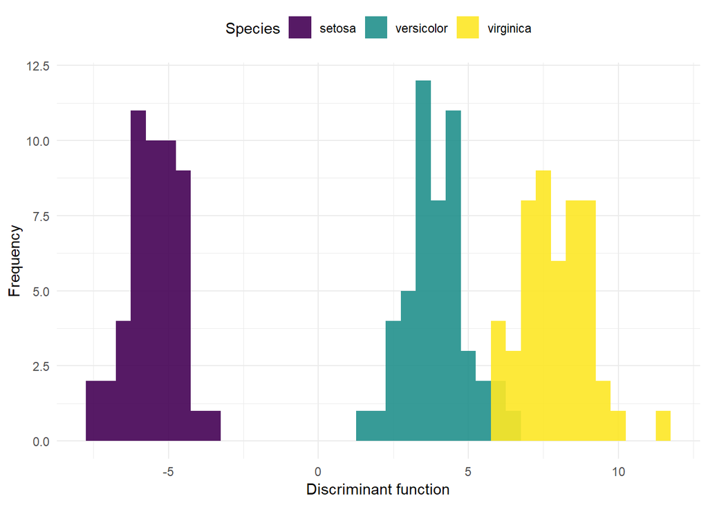

```r
# fit lda model, i.e. calculate model parameters
lda_iris <- lda(Species ~ ., data = iris)
pred_iris <- predict(lda_iris, type="response")$class

# use those parameters to compute the first linear discriminant
first_ld <- -c(as.matrix(iris[, -5]) %*% lda_iris$scaling[,1])

# plot
tibble(
  ld = first_ld,
  Species = iris$Species
) %>%
  ggplot(aes(x = ld, fill = Species)) +
  geom_histogram(binwidth = .5, position = "identity", alpha = .9) +
  scale_fill_viridis_d(guide = ) +
  theme_minimal() +
  labs(
    x = "Discriminant function",
    y = "Frequency",
    main = "Fisher's linear discriminant function on Iris species"
  ) +
  theme(legend.position = "top")
```

#### Question 8

```r
summary(iris)
```

```
##   Sepal.Length    Sepal.Width     Petal.Length    Petal.Width
##  Min.   :4.300   Min.   :2.000   Min.   :1.000   Min.   :0.100
##  1st Qu.:5.100   1st Qu.:2.800   1st Qu.:1.600   1st Qu.:0.300
##  Median :5.800   Median :3.000   Median :4.350   Median :1.300
##  Mean   :5.843   Mean   :3.057   Mean   :3.758   Mean   :1.199
##  3rd Qu.:6.400   3rd Qu.:3.300   3rd Qu.:5.100   3rd Qu.:1.800
##  Max.   :7.900   Max.   :4.400   Max.   :6.900   Max.   :2.500
##        Species
##  setosa    :50
##  versicolor:50
##  virginica :50
##
##
##
```

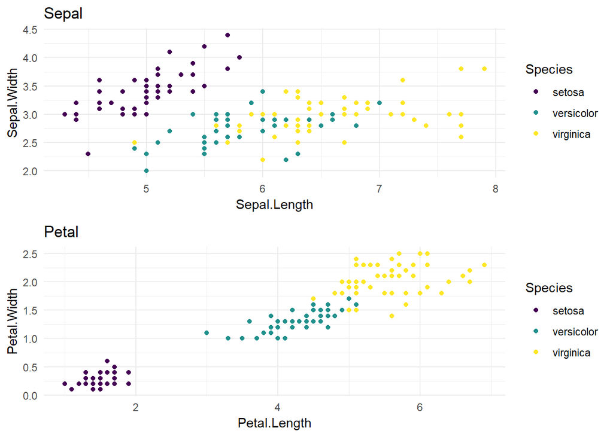

```r
#Plot of the length of the sepal

plot_sepal <- iris %>%
  ggplot(aes(x=Sepal.Length, y=Sepal.Width, color = Species)) +
  geom_point() +
  scale_color_viridis_d(guide=) +
  theme_minimal() +
  labs(title='Sepal')

plot_petal <- iris %>%
  ggplot(aes(x=Petal.Length, y=Petal.Width, color = Species)) +
  geom_point() +
  scale_color_viridis_d(guide=) +
  theme_minimal() +
  labs(title='Petal')

cowplot::plot_grid(plot_sepal, plot_petal, nrow=2, align='v')
```

The previous plot show the relation between Width and Lenght for respectively the Sepal and the petal. For the sepal the species are quite mixed and it’s not possible to underlines any pattern. Regarding the petal, the differenciation between the species is more visibles. The petals of the specie ‘Setosa’ have small length and width while the “Virginica”" one has big length and width. The specie “Versicolor” has medium petal’s length and width which is slighly overlapping the ‘Virginica’ one. On top of that, we can note that all the species follow a linear line characterizing the proportionnality between the lenght and the width of the petal. We can conclude that there is a strong separation between the species, comming from their petals shape.

#### Question 9

“Fit an additional LDA model, but this time with only Sepal.Length and Sepal.Width as predictors. Call this model lda_iris_sepal”

```r
lda_iris_sepal <- lda(Species ~ Sepal.Length + Sepal.Width, iris)
pred_iris_sepal = predict(lda_iris_sepal, type="response")$class
```

#### Question 10

“Create a confusion matrix of the lda_iris and lda_iris_sepal models. (NB: we did not split the dataset into training and test set, so use the training dataset to generate the predictions.). Which performs better in terms of accuracy?”

```r
matrix_iris <- table(true = iris$Species, pred = pred_iris)
matrix_iris_sepal <- table(true = iris$Species, pred = pred_iris_sepal)

matrix_iris
```

```
##             pred
## true         setosa versicolor virginica
##   setosa         50          0         0
##   versicolor      0         48         2
##   virginica       0          1        49
```

```r
matrix_iris_sepal
```

```
##             pred
## true         setosa versicolor virginica
##   setosa         49          1         0
##   versicolor      0         36        14
##   virginica       0         15        35
```

We can see that when using only the Sepal Width and Length the model doesn’t perform that well. In particular the species ‘Versicolor’ and ‘Virginica’ are mixed.

## Classification trees

#### Question 11

“Use rpart() to create a classification tree for the Species of iris. Call this model iris_tree_mod. Plot this model using rpart.plot().”

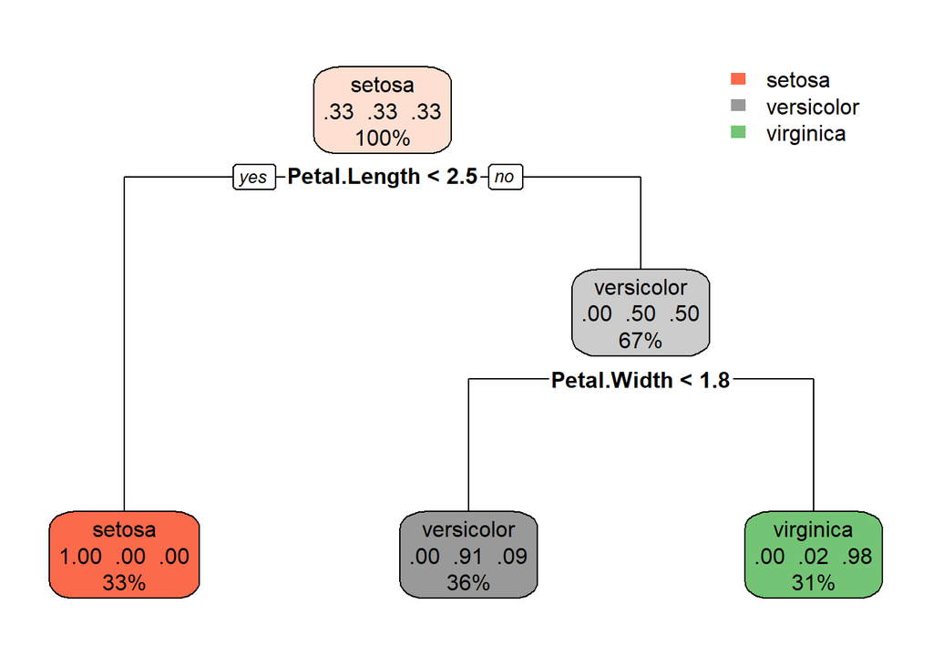

```r
iris_tree_mod <- rpart(Species ~., data=iris)
rpart.plot(iris_tree_mod)
```

#### Question 13

“Create a scatterplot where you map Petal.Length to the x position and Petal.Width to the y position. Then, manually add a vertical and a horizontal line (using geom_segment) at the locations of the splits from the classification tree. Interpret this plot.”

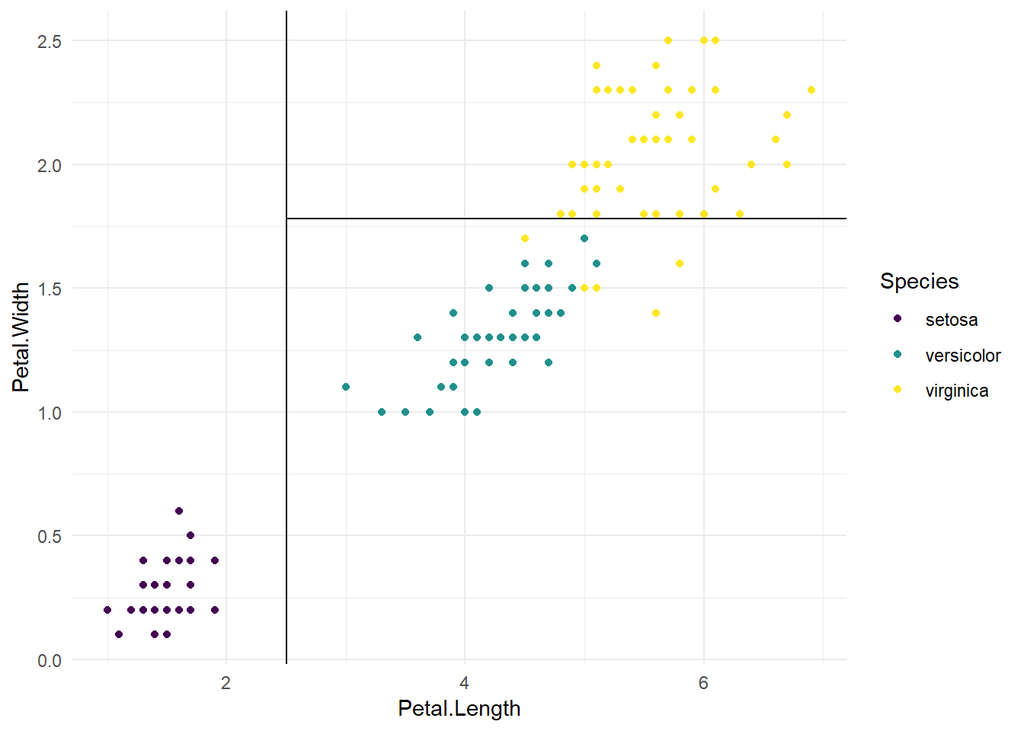

```r
iris %>%
  ggplot(aes(x=Petal.Length, y=Petal.Width, colour=Species)) +
  geom_point() +
  geom_segment(aes(x = 2.5, xend=2.5, y=-Inf, yend=Inf), colour="black") +
  geom_segment(aes(x= 2.5, xend=Inf, y=1.78, yend=1.78), colour="black") +
  scale_colour_viridis_d() +
  theme_minimal()
```

We can see that the ‘Setosa’ specie is always well classified as it’s clustererd and far from the other species. For ‘Virginica’ and ‘Versicolor’ some points overlap over each others, thus creating a miss classification.